# Reproducible Research PA 2-Coursera

## Impact of major weather events in the United States between 1950 and 2011

Aayush Shah

## **Data Processing**

```r
filename <- "repdata_data_StormData.csv.bz2"
if (!file.exists(filename)){
  url<-"https://d396qusza40orc.cloudfront.net/repdata%2Fdata%2Factivity.zip"
  download.file(url, filename, method="curl")
}
stormdata<-read.csv("repdata_data_StormData.csv.bz2")
```

## **Loading the Libraries**

```r
library(dplyr)
```

```r
library(ggplot2)
```

## **Addressing the question: Across the United States, which types of events are most harmful with respect to population health?**

To answer this question, I first created 2 subsets of *stormdata*, called *injuries* and *fatality*.

```r
injuries<-summarise(group_by(stormdata,EVTYPE,INJURIES))
fatality<-summarise(group_by(stormdata,EVTYPE,FATALITIES))
```

Then I selected only those entries from *injuries* and *fatality* which were not zero.

```r
fatality<-fatality[fatality$FATALITIES>0,]
injuries<-injuries[injuries$INJURIES>0,]
```

Now, I grouped the entries with same *EVNAME* in *injuries* and *fatality* and then added their values to create one single entry.

```r
fatality<-summarise(group_by(fatality,EVTYPE),FATALITIES=sum(FATALITIES))
injuries<-summarise(group_by(injuries,EVTYPE),INJURIES=sum(INJURIES))
```

So for example, multiple entries of *tornado* were collapsed to a single entry with total of all entries

Then I sorted *injuries* and *fatality* datasets in descending order

```r
injuries<-injuries[order(injuries$INJURIES,decreasing = TRUE),]
fatality<-fatality[order(fatality$FATALITIES,decreasing = TRUE),]
```

I viewed the top weather events which caused the maximum damage to population health.

```r
head(injuries)
```

```
## # A tibble: 6 x 2
##   EVTYPE            INJURIES
##   <fct>                <dbl>
## 1 TORNADO              26260
## 2 EXCESSIVE HEAT        5453
## 3 FLOOD                 4105
## 4 HEAT                  2059
## 5 ICE STORM             1858
## 6 HURRICANE/TYPHOON     1269
```

```r
head(fatality)
```

```
## # A tibble: 6 x 2
##   EVTYPE         FATALITIES
##   <fct>               <dbl>
## 1 TORNADO              1405
## 2 HEAT                  713
## 3 EXCESSIVE HEAT        711
## 4 HEAT WAVE             132
## 5 EXTREME HEAT           94
## 6 FLASH FLOOD            92
```

I merged the data sets *injuries* and *fatality* into a new dataset called *combineddata* and then added a new column to *combineddata* called *total* which simply adds the injuries and fatality values of the two data sets, *injuries* and *fatality*.Finally I sorted the *combineddata* according to its *total* values in descending order.

```r
combineddata<-merge(injuries,fatality,by="EVTYPE")
combineddata$total<- combineddata$INJURIES+combineddata$FATALITIES
combineddata<-combineddata[order(combineddata$total,decreasing = TRUE),]
```

As can be seen below,*tornados* have caused the most damage to human health from 1950 to 2011.

```r
head(combineddata)
```

```
##               EVTYPE INJURIES FATALITIES total
## 86           TORNADO    26260       1405 27665
## 14    EXCESSIVE HEAT     5453        711  6164
## 23             FLOOD     4105         64  4169
## 35              HEAT     2059        713  2772
## 54         ICE STORM     1858         21  1879
## 52 HURRICANE/TYPHOON     1269         39  1308
```

## **Addressing the question: Across the United States, which types of events have the greatest economic consequences?**

To answer this question, I created a subset of *stormdata* called *a* which extracted only columns *EVTYPE*, *PROPDMG*, *PROPDMGEXP*, *CROPDMG* and *CROPDMGEXP* from *stormdata*. Then I created *a1* which extracted entries of *a* whose *PROPDMGEXP* and *CROPDMGEXP* values were one of the following: “K”, “M”, “B”, ""(BLANK) corresponding to exponents: 1e+03, 1e+06, 1e+09 and 1 respectively

```
##    EVTYPE PROPDMG PROPDMGEXP CROPDMG CROPDMGEXP
## 1 TORNADO    25.0          K       0
## 2 TORNADO     2.5          K       0
## 3 TORNADO    25.0          K       0
## 4 TORNADO     2.5          K       0
## 5 TORNADO     2.5          K       0
## 6 TORNADO     2.5          K       0
```

```
## [1] "Dimensions of a are:"
```

```
## [1] 902297      5
```

```
##    EVTYPE PROPDMG PROPDMGEXP CROPDMG CROPDMGEXP
## 1 TORNADO    25.0          K       0
## 2 TORNADO     2.5          K       0
## 3 TORNADO    25.0          K       0
## 4 TORNADO     2.5          K       0
## 5 TORNADO     2.5          K       0
## 6 TORNADO     2.5          K       0
```

```
## [1] "Dimensions of a1 are:"
```

```
## [1] 901921      5
```

Then I converted *PROPDMGEXP* and *CROPDMGEXP* variables to their respective numeric values.

```r
propexp<-vector()
for ( i in 1:nrow(a1)){
  if (as.character(a1[i,3])=="K"){
    propexp[i]<-1000
  }
  if (as.character(a1[i,3])=="B"){
    propexp[i]<-1e+09
  }
  if (as.character(a1[i,3])=="M"){
    propexp[i]<-1e+06
  }
  if (as.character(a1[i,3])==""){
    propexp[i]<-1
  }
}
cropexp<-vector()
for ( i in 1:nrow(a1)){
  if (as.character(a1[i,5])=="K"){
    cropexp[i]<-1000
  }
  if (as.character(a1[i,5])=="B"){
    cropexp[i]<-1e+09
  }
  if (as.character(a1[i,5])=="M"){
    cropexp[i]<-1e+06
  }
  if (as.character(a1[i,5])==""){
    cropexp[i]<-1
  }
}
```

I combined the newly made vectors *cropexp* and *propexp* to *a1*

```r
a1<-cbind(a1,propexp,cropexp)
```

I made two new columns in *a1* called *propdamage* and *cropdamage* which multiplied *PROPDMG* and *CROPDMG* to its corresponding exponents *propexp* and *cropexp*

```r
a1$propdamage<-a1$PROPDMG*a1$propexp
a1$cropdamage<-a1$CROPDMG*a1$cropexp
```

Then i made two datasets called *propertydmg* and *cropdmg* which from *a1* and then selected only positive values and then grouped the entries with same *EVNAME* and then added their values to create one single entry and then sorted their values in descending order just like in question 1.

```r
propertydmg<-summarise(group_by(a1,EVTYPE,propdamage))
propertydmg<-propertydmg[propertydmg$propdamage>0,]
propertydmg<-summarise(group_by(propertydmg,EVTYPE),propdamage=sum(propdamage))
propertydmg<-propertydmg[order(propertydmg$propdamage,decreasing = TRUE),]
cropdmg<-summarise(group_by(a1,EVTYPE,cropdamage))
cropdmg<-cropdmg[cropdmg$cropdamage>0,]
cropdmg<-summarise(group_by(cropdmg,EVTYPE),cropdamage=sum(cropdamage))
cropdmg<-cropdmg[order(cropdmg$cropdamage,decreasing = TRUE),]
```

Finally I merged the data sets *propertydmg* and *cropdmg* into a new dataset called *combinedecodamage* and then added a new column to *combinedecodamage* called *total* which simply adds the property and crop damage costs of the two data sets, *cropdmg* and *propertydmg*.Finally I sorted the *combinedecodamage* according to its *total* values in descending order.

```r
combinedecodamage<-merge(propertydmg,cropdmg,by="EVTYPE")
combinedecodamage$total<-combinedecodamage$propdamage+combinedecodamage$cropdamage
combinedecodamage<-combinedecodamage[order(combinedecodamage$total,decreasing = TRUE),]
```

## **Results**

The following plot demonstrates that **tornados** are the most harmful weather event to population health:

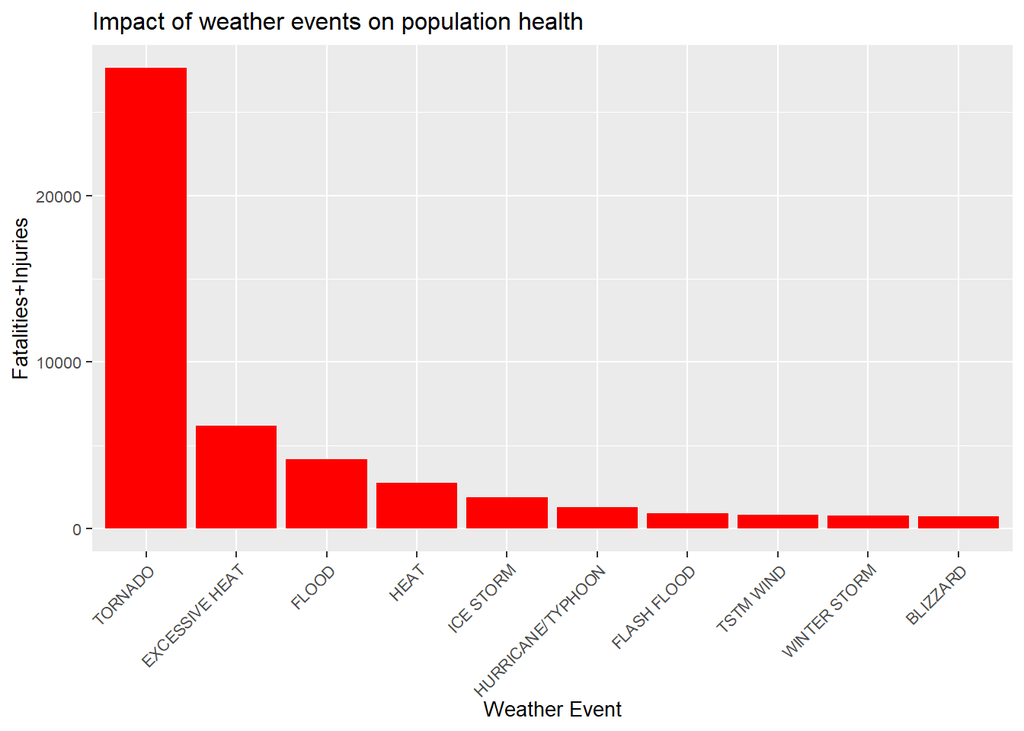

```r
ggplot(combineddata[1:10,],aes(x=reorder(EVTYPE, -total),y=total))+geom_bar(stat="identity",fill="red")+theme(text = element_text(size=10),axis.text.x = element_text(angle=45, hjust=1))+ggtitle("Impact of weather events on population health")+labs(x="Weather Event",y="Fatalities+Injuries")
```

The following plot demonstrates that **floods** have the greatest economic consequences:

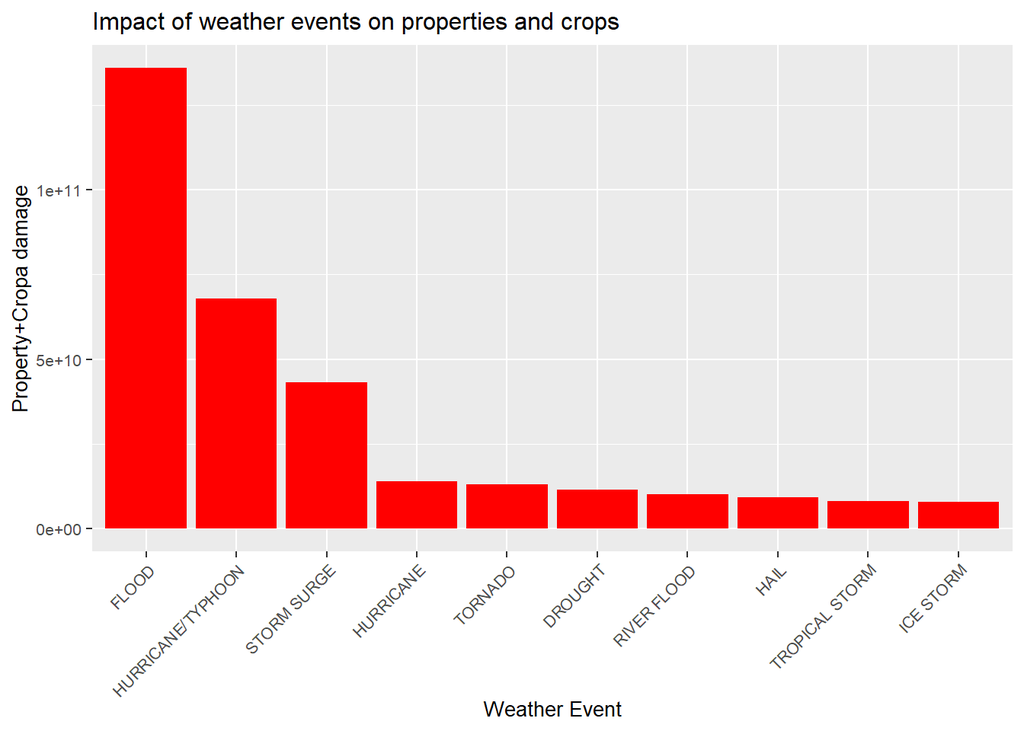

```r
ggplot(combinedecodamage[1:10,],aes(x=reorder(EVTYPE, -total),y=total))+geom_bar(stat="identity",fill="red")+theme(text = element_text(size=10),axis.text.x = element_text(angle=45, hjust=1))+ggtitle("Impact of weather events on properties and crops")+labs(x="Weather Event",y="Property+Cropa damage")
```

## **Conclusion**

1. *Tornados* have caused maximum harm to population health.
2. *Floods* have caused the most significant economic damage.

So, the government should allocate resources for weather disaster management accordingly.